# 20220508_climate_regionsTerraClimate

## 2022 EY Challenge - Weather Data

This notebook is used to create a weather dataset from **"TerraClimate"**. These data parameters, or their variability, can be used as "predictor variables" to relate to species samples. TerraClimate is a dataset of monthly climate and climatic water balance for global terrestrial surfaces from 1958-2019. These data provide important inputs for ecological and hydrological studies at global scales that require high spatial resolution and time-varying data. All data have monthly temporal resolution and a 4-km (0.036 degree) spatial resolution. The data can be found in the MS Planetary Computer catalog: https://planetarycomputer.microsoft.com/dataset/terraclimate

```python
# Supress Warnings
import warnings
warnings.filterwarnings('ignore')

# Import common GIS tools
import numpy as np
import xarray as xr
import matplotlib.pyplot as plt
import rasterio.features
import folium
import math

# Import Planetary Computer tools
import pystac_client
import planetary_computer
```

### Define the analysis region and view on a map

First, we define our area of interest using latitude and longitude coordinates. Our test region is Greater Sydney, NSW, Australia. The first line defines the lower-left corner of the bounding box and the second line defines the upper-right corner of the bounding box. GeoJSON format uses a specific order: (longitude, latitude), so be careful when entering the coordinates.

```python
# Greater Sydney, NSW
region_name = 'Greater Sydney, NSW'
min_lon, min_lat = (150.15, -34.25)  # Lower-left corner
max_lon, max_lat = (151.15, -33.25)  # Upper-right corner
bbox = (min_lon, min_lat, max_lon, max_lat)
latitude = (min_lat, max_lat)
longitude = (min_lon, max_lon)
```

```python
bboxes = [(144.8,-38.5,145.8,-37.5),
          (150.7,-33.5,151.7,-32.5),
          (152.6,-29.0,153.6,-28.0),
         (145.0,-17.7,146.0,-16.7),
         (115.7,-32.5,116.7,-31.5)]
```

### Discover and load the data for analysis

Using **pystac**, we will load the collection with links to all of the metadata about this dataset. The collection contains assets, which are links to the root of a Zarr store, which can be opened with xarray. Once loaded and opened, we can select the parameters we desire for further analyses. Overall, there are 18 variables for consideration. You can click the "Data Variables" output "arrow" for a list of those parameters.

```python
import pystac
collection = pystac.read_file("https://planetarycomputer.microsoft.com/api/stac/v1/collections/terraclimate")
asset = collection.assets["zarr-https"]
```

```python
import fsspec
import xarray as xr

store = fsspec.get_mapper(asset.href)
data = xr.open_zarr(store, **asset.extra_fields["xarray:open_kwargs"])
```

```python
# View the dimensions, coordinates and variables of the dataset
data
```

```
<xarray.Dataset>
Dimensions:                 (time: 744, lat: 4320, lon: 8640, crs: 1)
Coordinates:
  * crs                     (crs) int16 3
  * lat                     (lat) float64 89.98 89.94 89.9 ... -89.94 -89.98
  * lon                     (lon) float64 -180.0 -179.9 -179.9 ... 179.9 180.0
  * time                    (time) datetime64[ns] 1958-01-01 ... 2019-12-01
Data variables: (12/18)
    aet                     (time, lat, lon) float32 dask.array<chunksize=(12, 1440, 1440), meta=np.ndarray>
    def                     (time, lat, lon) float32 dask.array<chunksize=(12, 1440, 1440), meta=np.ndarray>
    pdsi                    (time, lat, lon) float32 dask.array<chunksize=(12, 1440, 1440), meta=np.ndarray>
    pet                     (time, lat, lon) float32 dask.array<chunksize=(12, 1440, 1440), meta=np.ndarray>
    ppt                     (time, lat, lon) float32 dask.array<chunksize=(12, 1440, 1440), meta=np.ndarray>
    ppt_station_influence   (time, lat, lon) float32 dask.array<chunksize=(12, 1440, 1440), meta=np.ndarray>
    ...                      ...
    tmin                    (time, lat, lon) float32 dask.array<chunksize=(12, 1440, 1440), meta=np.ndarray>
    tmin_station_influence  (time, lat, lon) float32 dask.array<chunksize=(12, 1440, 1440), meta=np.ndarray>
    vap                     (time, lat, lon) float32 dask.array<chunksize=(12, 1440, 1440), meta=np.ndarray>
    vap_station_influence   (time, lat, lon) float32 dask.array<chunksize=(12, 1440, 1440), meta=np.ndarray>
    vpd                     (time, lat, lon) float32 dask.array<chunksize=(12, 1440, 1440), meta=np.ndarray>
    ws                      (time, lat, lon) float32 dask.array<chunksize=(12, 1440, 1440), meta=np.ndarray>
```

### Parsing the dataset

Assuming we do not need all 18 variables and global coverage, we will "clip" the data to our region and select a time window that is representative of weather over this area (e.g. 5 years). Finally, we will select the variables we think are most likely to be "predictor variables" for frog species habitats. These are:  
maximum air temperature (tmax) - 2 meters above surface  
minimum air temperature (tmin) - 2 meters above surface  
accumulated precipitation (ppt) - accumulated monthly in millimeters  
soil moisture (soil) - soil moisture in millimeters at end of month

```python
for i in range(len(bboxes)):
    clipped_data = data.sel(lon=slice(bboxes[i][0], bboxes[i][2]),lat=slice(bboxes[i][3], bboxes[i][1]),time=slice('2015-01-01','2022-12-31'))
    parsed_data = clipped_data[['tmax', 'tmin', 'ppt', 'soil']]
    fig = plt.figure(figsize=(12, 6))
    parsed_data["tmax"].mean(dim=["lat","lon"]).plot(marker='o',markersize=4,linewidth=1)
    parsed_data["tmin"].mean(dim=["lat","lon"]).plot(marker='o',markersize=4,linewidth=1)
    plt.title("Mean Monthly Maximum and Minimum Air Temperature")
    plt.show()
```

[output not shown]

[output cut: 32 more lines]

[output not shown]

```python
parsed_data_list = []
for i in range(len(bboxes)):
    clipped_data = data.sel(lon=slice(bboxes[i][0], bboxes[i][2]),lat=slice(bboxes[i][3], bboxes[i][1]),time=slice('2015-01-01','2022-12-31'))
    parsed_data = clipped_data[['tmax', 'tmin', 'ppt', 'soil']]
    parsed_data_list.append(parsed_data)
```

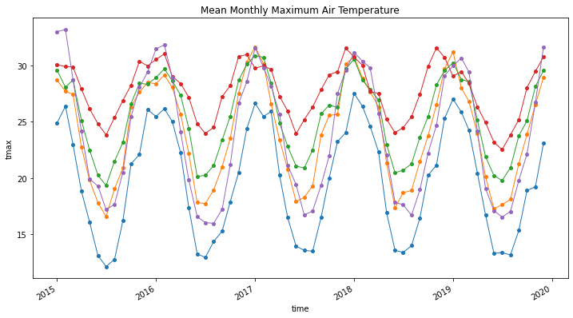

```python
fig = plt.figure(figsize=(12, 6))
for i in range(len(bboxes)):
    parsed_data = parsed_data_list[i]
    parsed_data["tmax"].mean(dim=["lat","lon"]).plot(marker='o',markersize=4,linewidth=1)
plt.title("Mean Monthly Maximum Air Temperature")
plt.show()
```

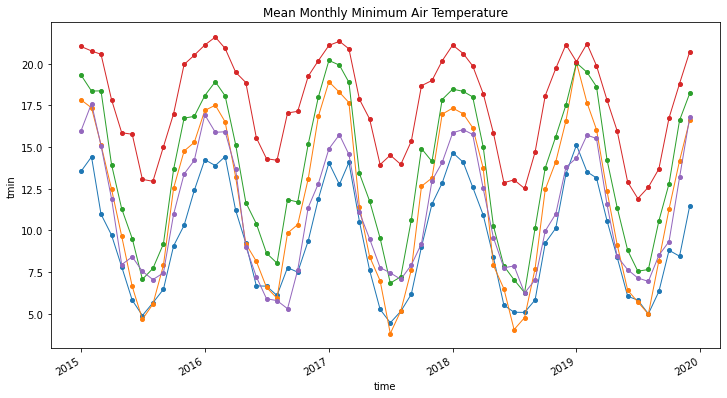

```python
fig = plt.figure(figsize=(12, 6))
for i in range(len(bboxes)):
    parsed_data = parsed_data_list[i]
    parsed_data["tmin"].mean(dim=["lat","lon"]).plot(marker='o',markersize=4,linewidth=1)
plt.title("Mean Monthly Minimum Air Temperature")
plt.show()
```

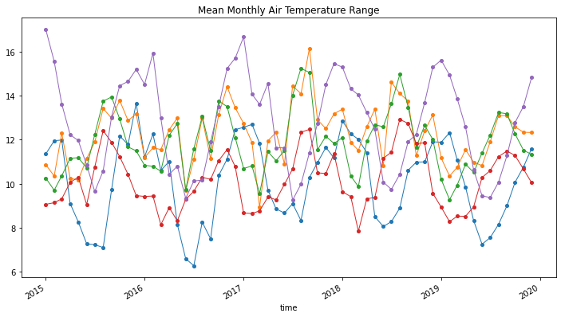

```python
fig = plt.figure(figsize=(12, 6))
for i in range(len(bboxes)):
    parsed_data = parsed_data_list[i]
    ((parsed_data['tmax'].mean(dim=['lat','lon'])) - (parsed_data["tmin"].mean(dim=["lat","lon"]))).plot(marker='o',markersize=4,linewidth=1)
plt.title("Mean Monthly Air Temperature Range")
plt.show()
```

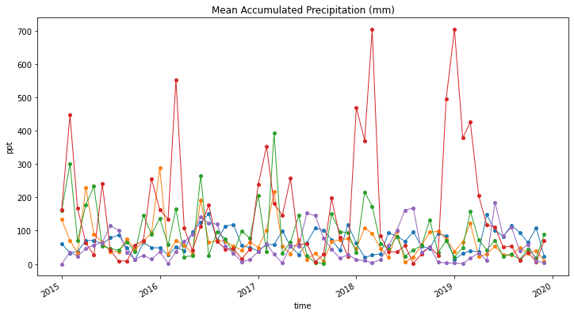

```python
fig = plt.figure(figsize=(12, 6))
for i in range(len(bboxes)):
    parsed_data = parsed_data_list[i]
    precip = parsed_data["ppt"].mean(dim=["lat","lon"]).plot(marker='o',markersize=4,linewidth=1)
plt.title("Mean Accumulated Precipitation (mm)")
plt.show()
```

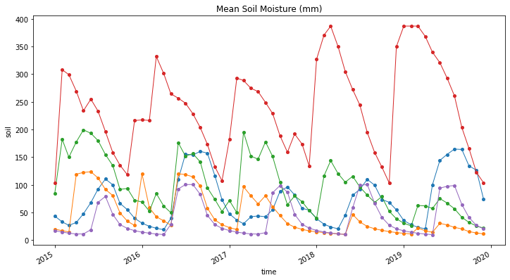

```python
fig = plt.figure(figsize=(12, 6))
for i in range(len(bboxes)):
    parsed_data = parsed_data_list[i]
    moisture = parsed_data["soil"].mean(dim=["lat","lon"]).plot(marker='o',markersize=4,linewidth=1)
plt.title("Mean Soil Moisture (mm)")
plt.show()
```

```python
time_subslice = slice('2016-12-01','2018-02-01')
```

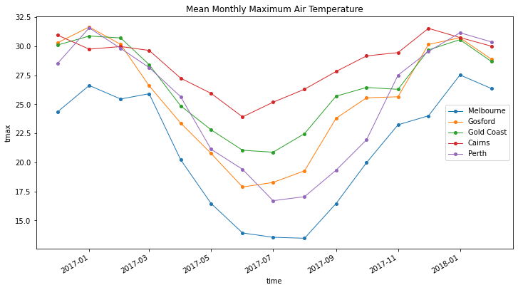

```python
fig = plt.figure(figsize=(12, 6))
for i in range(len(bboxes)):
    parsed_data = parsed_data_list[i]
    parsed_data = parsed_data.sel(time=slice('2016-12-01','2018-02-01'))
    parsed_data["tmax"].mean(dim=["lat","lon"]).plot(marker='o',markersize=4,linewidth=1)
plt.title("Mean Monthly Maximum Air Temperature")
plt.legend(['Melbourne','Gosford','Gold Coast','Cairns','Perth'], loc='center right')
plt.show()
```

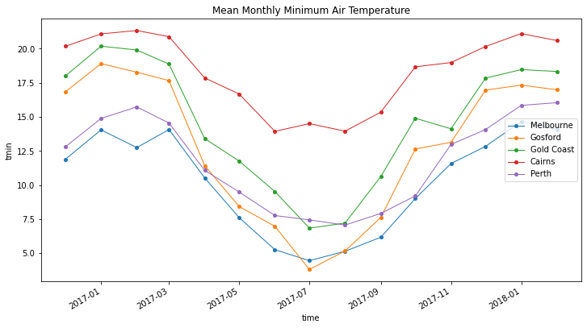

```python
fig = plt.figure(figsize=(12, 6))
for i in range(len(bboxes)):
    parsed_data = parsed_data_list[i]
    parsed_data = parsed_data.sel(time=slice('2016-12-01','2018-02-01'))
    parsed_data["tmin"].mean(dim=["lat","lon"]).plot(marker='o',markersize=4,linewidth=1)
plt.title("Mean Monthly Minimum Air Temperature")
plt.legend(['Melbourne','Gosford','Gold Coast','Cairns','Perth'], loc='center right')

plt.show()
```

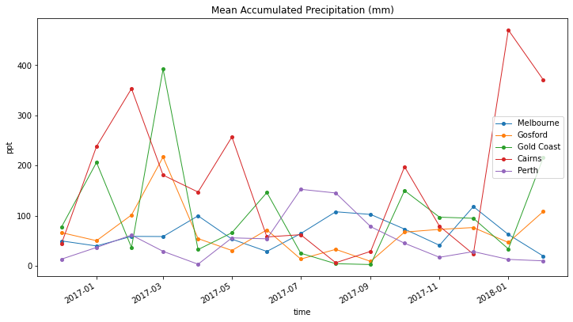

```python
fig = plt.figure(figsize=(12, 6))
for i in range(len(bboxes)):
    parsed_data = parsed_data_list[i]
    parsed_data = parsed_data.sel(time=slice('2016-12-01','2018-02-01'))
    precip = parsed_data["ppt"].mean(dim=["lat","lon"]).plot(marker='o',markersize=4,linewidth=1)
plt.title("Mean Accumulated Precipitation (mm)")
plt.legend(['Melbourne','Gosford','Gold Coast','Cairns','Perth'], loc='center right')
plt.show()
```

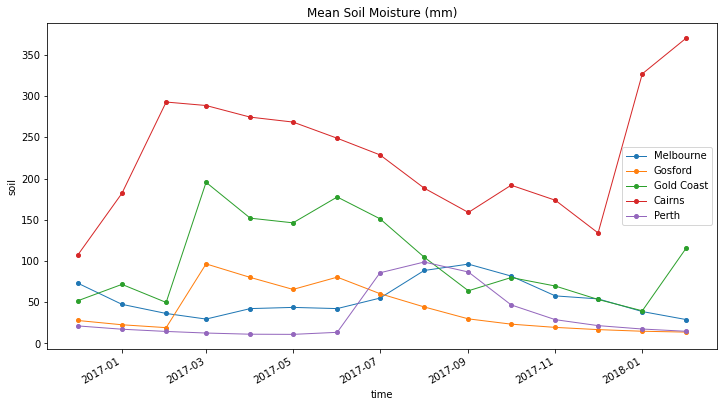

```python
fig = plt.figure(figsize=(12, 6))
for i in range(len(bboxes)):
    parsed_data = parsed_data_list[i]
    parsed_data = parsed_data.sel(time=slice('2016-12-01','2018-02-01'))
    moisture = parsed_data["soil"].mean(dim=["lat","lon"]).plot(marker='o',markersize=4,linewidth=1)
plt.title("Mean Soil Moisture (mm)")
plt.legend(['Melbourne','Gosford','Gold Coast','Cairns','Perth'], loc='center right')
plt.show()
```

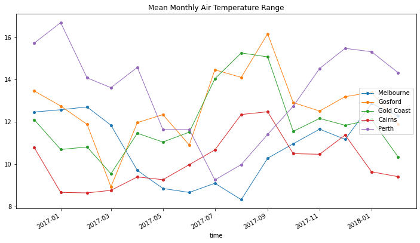

```python
fig = plt.figure(figsize=(12, 6))
for i in range(len(bboxes)):
    parsed_data = parsed_data_list[i]
    parsed_data = parsed_data.sel(time=slice('2016-12-01','2018-02-01'))
    ((parsed_data['tmax'].mean(dim=['lat','lon'])) - (parsed_data["tmin"].mean(dim=["lat","lon"]))).plot(marker='o',markersize=4,linewidth=1)
plt.title("Mean Monthly Air Temperature Range")
plt.legend(['Melbourne','Gosford','Gold Coast','Cairns','Perth'], loc='center right')
plt.show()
```

```python
for i in range(len(bboxes)):
    clipped_data = data.sel(lon=slice(bboxes[i][0], bboxes[i][2]),lat=slice(bboxes[i][3], bboxes[i][1]),time=time_subslice)
    parsed_data = clipped_data[['tmax', 'tmin', 'ppt', 'soil']]
    precip.plot(figsize=(12, 6),marker='o',markersize=4,linewidth=1)
    plt.title("Mean Accumulated Precipitation (mm)")
    plt.show()
```

[figure not shown]

[figure not shown]

[figure not shown]

[figure not shown]

[figure not shown]

```python
for i in range(len(bboxes)):
    clipped_data = data.sel(lon=slice(bboxes[i][0], bboxes[i][2]),lat=slice(bboxes[i][3], bboxes[i][1]),time=time_subslice)
    parsed_data = clipped_data[['tmax', 'tmin', 'ppt', 'soil']]
    precip = (parsed_data["ppt"]).mean(dim=["lat","lon"])
    precip.plot(figsize=(12, 6),marker='o',markersize=4,linewidth=1)
    plt.title("Mean Accumulated Precipitation (mm)")
    plt.show()
```

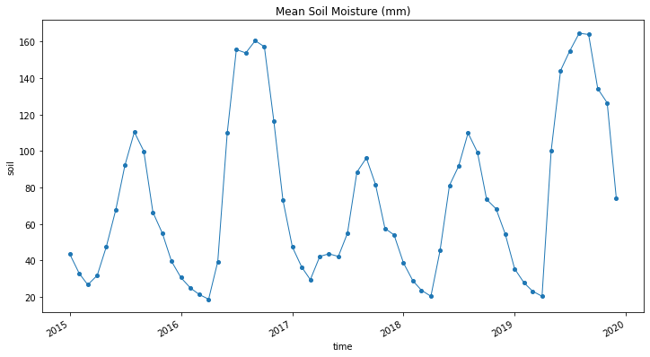

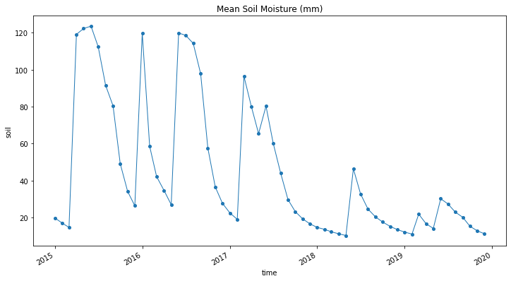

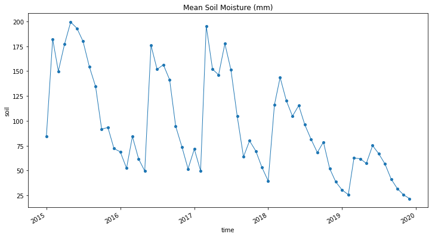

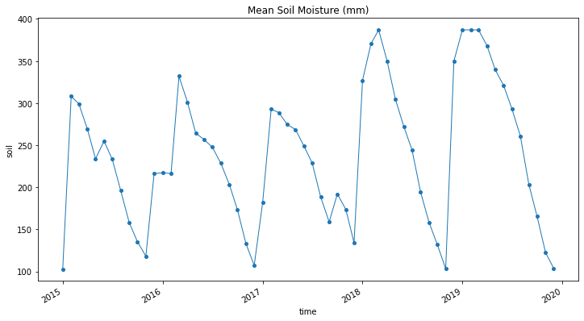

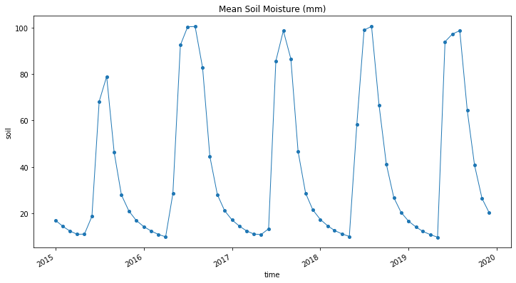

```python
for i in range(len(bboxes)):
    clipped_data = data.sel(lon=slice(bboxes[i][0], bboxes[i][2]),lat=slice(bboxes[i][3], bboxes[i][1]),time=slice('2015-01-01','2019-12-31'))
    parsed_data = clipped_data[['tmax', 'tmin', 'ppt', 'soil']]
    # Soil Moisture
    moisture = (parsed_data["soil"]).mean(dim=["lat","lon"])
    moisture.plot(figsize=(12, 6),marker='o',markersize=4,linewidth=1)
    plt.title("Mean Soil Moisture (mm)")
    plt.show()
```

```python
parsed_data = clipped_data[['tmax', 'tmin', 'ppt', 'soil']]
```

```python
# View the dimensions, coordinates and variables of the dataset
parsed_data
```

[output not shown]

### Data Analysis

Now we will look closer at some of this data using plotting and statistics.

### How will the participants use this data?

```python
val_maxtemp = parsed_data.tmax.mean(dim=["time"]).sel(lon=150.71, lat=-33.51, method="nearest").values
print("This is the mean maximum air temperature for the closest pixel: ", np.round(val_maxtemp,1))
val_allmaxtemp = parsed_data.tmax.max(dim=["time"]).sel(lon=150.71, lat=-33.51, method="nearest").values
print("This is the overall maximum air temperature for the closest pixel: ", np.round(val_allmaxtemp,1))
val_mintemp = parsed_data.tmin.mean(dim=["time"]).sel(lon=150.71, lat=-33.51, method="nearest").values
print("This is the mean minimum air temperature for the closest pixel: ", np.round(val_mintemp,1))
val_allmintemp = parsed_data.tmin.min(dim=["time"]).sel(lon=150.71, lat=-33.51, method="nearest").values
print("This is the overall minimum air temperature for the closest pixel: ", np.round(val_allmintemp,1))
val_precip = parsed_data.ppt.mean(dim=["time"]).sel(lon=150.71, lat=-33.51, method="nearest").values
print("This is the mean accumulated precipitation for the closest pixel: ", np.round(val_precip,1))
val_soil = parsed_data.soil.mean(dim=["time"]).sel(lon=150.71, lat=-33.51, method="nearest").values
print("This is the mean soil moisture for the closest pixel: ", np.round(val_soil,1))
```

```
This is the mean maximum air temperature for the closest pixel:  24.4
This is the overall maximum air temperature for the closest pixel:  32.4
This is the mean minimum air temperature for the closest pixel:  11.2
This is the overall minimum air temperature for the closest pixel:  2.6
This is the mean accumulated precipitation for the closest pixel:  62.5
This is the mean soil moisture for the closest pixel:  31.0
```

### Saving the time series data in CSV format

Now, what if you want to save the time series data for a particular parameter and Lat-Lon location? We can use the example above to specify a Lat-Lon position and then save the time series soil moisture data for that location. Below is the code that will create this CSV file. The file will contain columns for time (month), latitude and longitude (for the nearest pixel) and soil moisture.

```python
filename = "Soil_Moisture_sample.csv"
parsed_data["soil"].sel(lon=150.71, lat=-33.51, method="nearest").to_dataframe().to_csv(filename)
```

```python
# Show the location and size of the new output file
!ls *.csv -lah
```

```
-rw-r--r-- 1 jovyan users 3.3K Jan  6 01:23 Soil_Moisture_sample.csv
```